# Project 3 - Retail

# Time Series Model

```python
dttest_time=pd.read_csv("C:\\Users\\Subhasish Das\\Desktop\\SimplyLearn\\Project\\AICapston\\Retail-Datasets\\test_data.csv")
dttr_time=pd.read_csv("C:\\Users\\Subhasish Das\\Desktop\\SimplyLearn\\Project\\AICapston\\Retail-Datasets\\train_data.csv")
dthidd_time=pd.read_csv("C:\\Users\\Subhasish Das\\Desktop\\SimplyLearn\\Project\\AICapston\\Retail-Datasets\\test_data_hidden.csv")
```

```
C:\Users\Subhasish Das\Anaconda3\lib\site-packages\IPython\core\interactiveshell.py:3049: DtypeWarning: Columns (7) have mixed types. Specify dtype option on import or set low_memory=False.
  interactivity=interactivity, compiler=compiler, result=result)
```

```python
dtmer_time=pd.concat([dttr_time,dthidd_time])
```

```python
dtmer_time['Date']=pd.to_datetime(dtmer_time['Date'])
```

```python
dtmer_time.dtypes
```

```
Store                     int64
DayOfWeek                 int64
Date             datetime64[ns]
Sales                     int64
Customers                 int64
Open                      int64
Promo                     int64
StateHoliday             object
SchoolHoliday             int64
dtype: object
```

```python
dtmer_time['Year']=pd.DatetimeIndex(dtmer_time['Date']).year
dtmer_time['Month']=pd.DatetimeIndex(dtmer_time['Date']).month
```

```python
dtmer_time.drop(['DayOfWeek','Customers','Open','Promo','StateHoliday','SchoolHoliday'],axis=1,inplace=True)
```

```python
dtmer_time=dtmer_time.set_index('Date')
```

```python
dtmer_time.head()
```

| Date | Store | Sales | Year | Month |
| --- | --- | --- | --- | --- |
| 2015-06-30 | 1 | 5735 | 2015 | 6 |
| 2015-06-30 | 2 | 9863 | 2015 | 6 |
| 2015-06-30 | 3 | 13261 | 2015 | 6 |
| 2015-06-30 | 4 | 13106 | 2015 | 6 |
| 2015-06-30 | 5 | 6635 | 2015 | 6 |

```python
dtmer_time.Year.unique()
```

```
array([2015, 2014, 2013], dtype=int64)
```

```python
dtmer_time['Season']=''
```

```python
dtmer_time.head()
```

| Date | Store | Sales | Year | Month | Season |
| --- | --- | --- | --- | --- | --- |
| 2015-06-30 | 1 | 5735 | 2015 | 6 |  |
| 2015-06-30 | 2 | 9863 | 2015 | 6 |  |
| 2015-06-30 | 3 | 13261 | 2015 | 6 |  |
| 2015-06-30 | 4 | 13106 | 2015 | 6 |  |
| 2015-06-30 | 5 | 6635 | 2015 | 6 |  |

```python
def getSeason(month):
    if (month == 12) or (month == 1) or (month == 2 or month == 3):
       return "WINTER"
    elif(month == 4) or (month == 5):
       return "SPRING"
    elif(month ==6) or (month==7) or (month == 8) or (month == 9):
       return "SUMMER"
    else:
       return "FALL"
```

```python
dtmer_time['Season']=dtmer_time['Month'].apply(getSeason)
```

```python
sns.set(rc={'figure.figsize':(11, 8)})
```

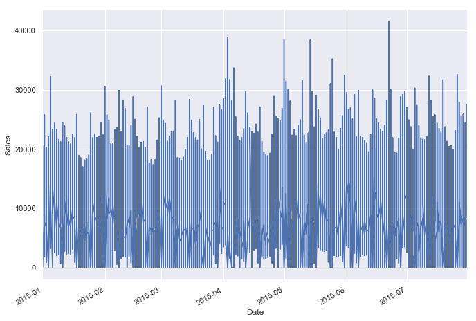

```python
ax = dtmer_time.loc['2015', 'Sales'].plot()
ax.set_ylabel('Sales');
```

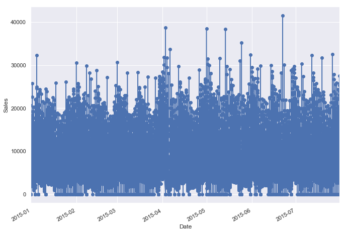

```python
ax = dtmer_time.loc['2015', 'Sales'].plot(marker='o', linestyle='-')
ax.set_ylabel('Sales');
```

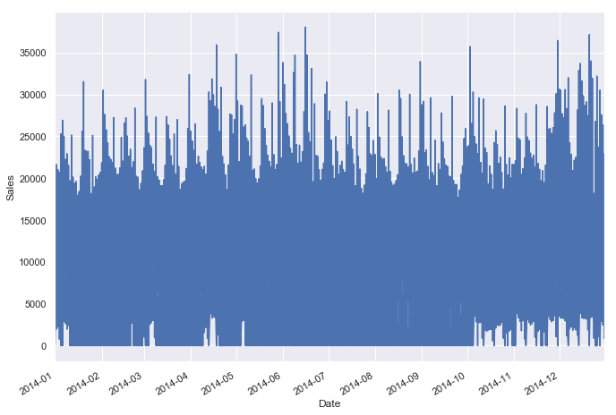

```python
ax=dtmer_time.loc['2014','Sales'].plot()
ax.set_ylabel('Sales');
```

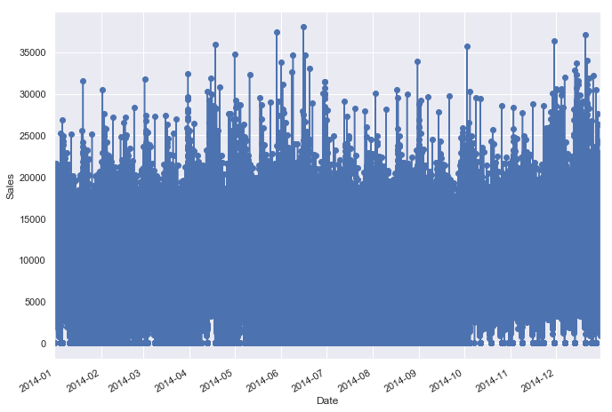

```python
ax=dtmer_time.loc['2014','Sales'].plot(marker='o', linestyle='-')
ax.set_ylabel('Sales');
```

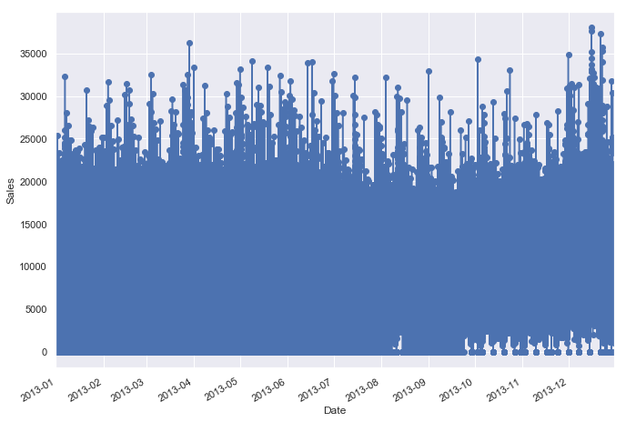

```python
ax=dtmer_time.loc['2013','Sales'].plot(marker='o', linestyle='-')
ax.set_ylabel('Sales');
```

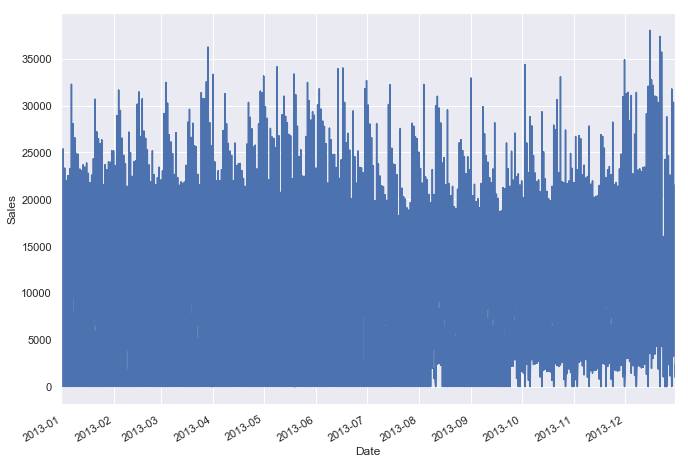

```python
ax=dtmer_time.loc['2013','Sales'].plot()
ax.set_ylabel('Sales');
```

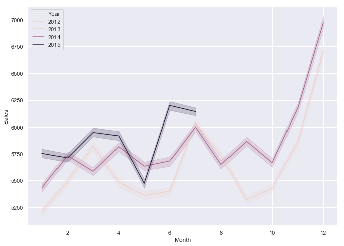

```python
sns.lineplot(data=dtmer_time, x='Month', y='Sales',hue='Year');
```

###### Observation - 8

> From the above plot we can say that for merged data set in the year 2014 and December month Sale was highest

```python
dttr_time['Date']=pd.to_datetime(dttr_time['Date'])
```

```python
dttr_time.dtypes
```

```
Store                     int64
DayOfWeek                 int64
Date             datetime64[ns]
Sales                     int64
Customers                 int64
Open                      int64
Promo                     int64
StateHoliday             object
SchoolHoliday             int64
dtype: object
```

```python
dttr_time['Year']=pd.DatetimeIndex(dttr_time['Date']).year
dttr_time['Month']=pd.DatetimeIndex(dttr_time['Date']).month
```

```python
dttr_time.drop(['DayOfWeek','Customers','Open','Promo','StateHoliday','SchoolHoliday'],axis=1,inplace=True)
```

```python
dttr_time=dttr_time.set_index('Date')
```

```python
dttr_time.head()
```

| Date | Store | Sales | Year | Month |
| --- | --- | --- | --- | --- |
| 2015-06-30 | 1 | 5735 | 2015 | 6 |
| 2015-06-30 | 2 | 9863 | 2015 | 6 |
| 2015-06-30 | 3 | 13261 | 2015 | 6 |
| 2015-06-30 | 4 | 13106 | 2015 | 6 |
| 2015-06-30 | 5 | 6635 | 2015 | 6 |

```python
dttr_time['Season']=''
```

```python
dttr_time['Season']=dttr_time['Month'].apply(getSeason)
```

```python
dttr_time.Year.unique()
```

```
array([2015, 2014, 2013], dtype=int64)
```

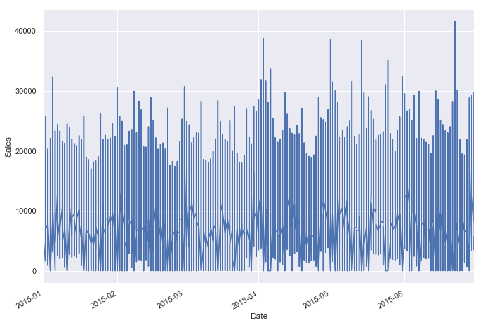

```python
ax = dttr_time.loc['2015', 'Sales'].plot()
ax.set_ylabel('Sales');
```

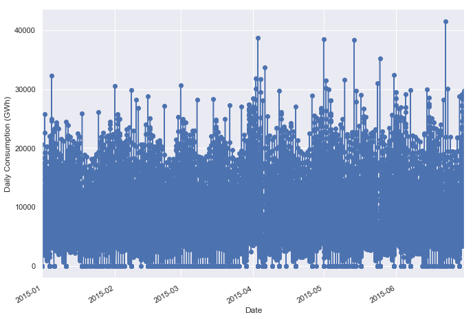

```python
ax = dttr_time.loc['2015', 'Sales'].plot(marker='o', linestyle='-')
ax.set_ylabel('Daily Consumption (GWh)');
```

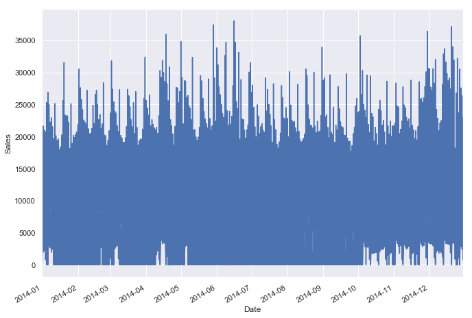

```python
ax = dttr_time.loc['2014', 'Sales'].plot()
ax.set_ylabel('Sales');
```

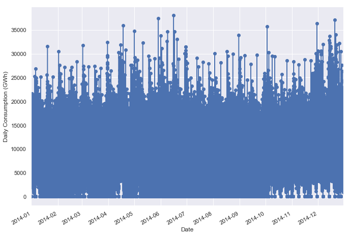

```python
ax = dttr_time.loc['2014', 'Sales'].plot(marker='o', linestyle='-')
ax.set_ylabel('Daily Consumption (GWh)');
```

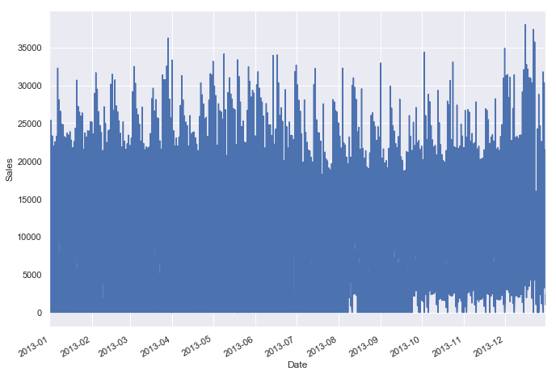

```python
ax = dttr_time.loc['2013', 'Sales'].plot()
ax.set_ylabel('Sales');
```

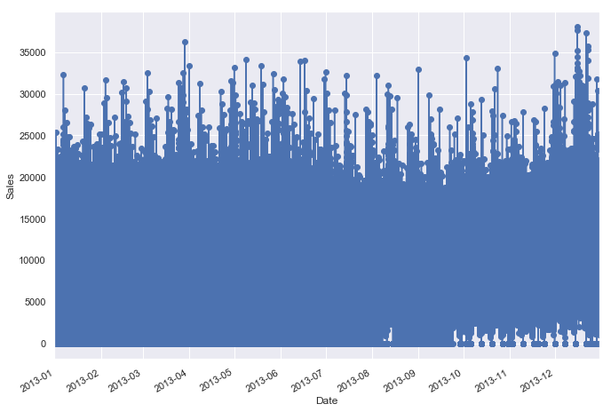

```python
ax = dttr_time.loc['2013', 'Sales'].plot(marker='o', linestyle='-')
ax.set_ylabel('Sales');
```

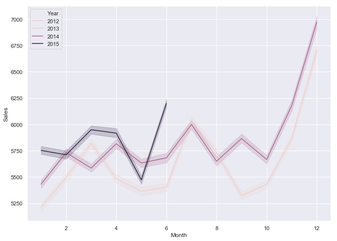

```python
sns.lineplot(data=dttr_time, x='Month', y='Sales',hue='Year');
```

###### Observation - 9

> From the above plot we can say that for training data set in the year 2014 and December month Sale was highest

```python
dthidd_time.dtypes
```

```
Store             int64
DayOfWeek         int64
Date             object
Sales             int64
Customers         int64
Open              int64
Promo             int64
StateHoliday      int64
SchoolHoliday     int64
dtype: object
```

```python
dthidd_time['Date']=pd.to_datetime(dthidd_time['Date'])
```

```python
dthidd_time['Year']=pd.DatetimeIndex(dthidd_time['Date']).year
dthidd_time['Month']=pd.DatetimeIndex(dthidd_time['Date']).month
```

```python
dthidd_time.drop(['DayOfWeek','Customers','Open','Promo','StateHoliday','SchoolHoliday'],axis=1,inplace=True)
```

```python
dthidd_time=dthidd_time.set_index('Date')
```

```python
dthidd_time['Season']=''
dthidd_time['Season']=dthidd_time['Month'].apply(getSeason)
```

```python
dthidd_time.Year.unique()
```

```
array([2015], dtype=int64)
```

```python
dthidd_time.Season.unique()
```

```
array(['SUMMER'], dtype=object)
```

```python
dthidd_time.head()
```

| Date | Store | Sales | Year | Month | Season |
| --- | --- | --- | --- | --- | --- |
| 2015-07-31 | 1 | 5263 | 2015 | 7 | SUMMER |
| 2015-07-31 | 2 | 6064 | 2015 | 7 | SUMMER |
| 2015-07-31 | 3 | 8314 | 2015 | 7 | SUMMER |
| 2015-07-31 | 4 | 13995 | 2015 | 7 | SUMMER |
| 2015-07-31 | 5 | 4822 | 2015 | 7 | SUMMER |

```python
dthidd_time.dtypes
```

```
Store      int64
Sales      int64
Year       int64
Month      int64
Season    object
dtype: object
```

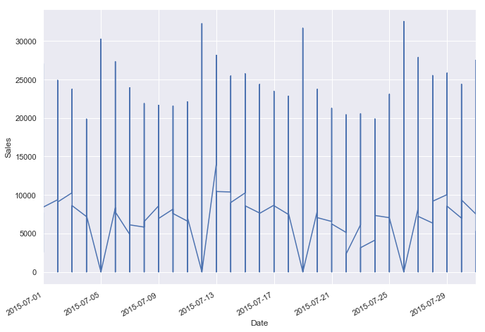

```python
ax = dthidd_time.loc['2015', 'Sales'].plot()
ax.set_ylabel('Sales');
```

[figure not shown]

```python
sns.lineplot(data=dthidd_time, x='Month', y='Sales',hue='Year')
```

## Project Task: Week 3

**Implementing Neural Networks:**

1. Train a LSTM on the same set of features and compare the result with traditional time-series model.
2. Comment on the behavior of all the models you have built so far
3. Cluster stores using sales and customer visits as features. Find out how many clusters or groups are possible. Also visualize the results.
4. Is it possible to have separate prediction models for each cluster? Compare results with the previous models.

### Code :

```python
dttest_time_lstm=pd.read_csv("C:\\Users\\Subhasish Das\\Desktop\\SimplyLearn\\Project\\AICapston\\Retail-Datasets\\test_data.csv")
dttr_time_lstm=pd.read_csv("C:\\Users\\Subhasish Das\\Desktop\\SimplyLearn\\Project\\AICapston\\Retail-Datasets\\train_data.csv")
dthidd_time_lstm=pd.read_csv("C:\\Users\\Subhasish Das\\Desktop\\SimplyLearn\\Project\\AICapston\\Retail-Datasets\\test_data_hidden.csv")
```

```
C:\Users\Subhasish Das\Anaconda3\lib\site-packages\IPython\core\interactiveshell.py:3049: DtypeWarning: Columns (7) have mixed types. Specify dtype option on import or set low_memory=False.
  interactivity=interactivity, compiler=compiler, result=result)
```

```python
dttr_time_lstm['Date']=pd.to_datetime(dttr_time_lstm['Date'])
```

```python
dttr_time_lstm['Year']=pd.DatetimeIndex(dttr_time_lstm['Date']).year
dttr_time_lstm['Month']=pd.DatetimeIndex(dttr_time_lstm['Date']).month
```

```python
dttr_time_lstm.drop(['DayOfWeek','Customers','Open','Promo','StateHoliday','SchoolHoliday'],axis=1,inplace=True)
```

```python
dttr_time_lstm['Season']=''
dttr_time_lstm['Season']=dttr_time_lstm['Month'].apply(getSeason)
```

```python
dttest_time_lstm['Date']=pd.to_datetime(dttest_time_lstm['Date'])
```

```python
dttest_time_lstm['Year']=pd.DatetimeIndex(dttest_time_lstm['Date']).year
dttest_time_lstm['Month']=pd.DatetimeIndex(dttest_time_lstm['Date']).month
```

```python
dttest_time_lstm.drop(['DayOfWeek','Customers','Open','Promo','StateHoliday','SchoolHoliday'],axis=1,inplace=True)
```

```python
dttest_time_lstm['Season']=''
dttest_time_lstm['Season']=dttest_time_lstm['Month'].apply(getSeason)
```

```python
dthidd_time_lstm['Date']=pd.to_datetime(dthidd_time_lstm['Date'])
```

```python
dthidd_time_lstm['Year']=pd.DatetimeIndex(dthidd_time_lstm['Date']).year
dthidd_time_lstm['Month']=pd.DatetimeIndex(dthidd_time_lstm['Date']).month
```

```python
dthidd_time_lstm.drop(['DayOfWeek','Customers','Open','Promo','StateHoliday','SchoolHoliday'],axis=1,inplace=True)
```

```python
dthidd_time_lstm['Season']=''
dthidd_time_lstm['Season']=dthidd_time_lstm['Month'].apply(getSeason)
```

```python
dthidd_time_lstm.head()
```

|  | Store | Date | Sales | Year | Month | Season |
| --- | --- | --- | --- | --- | --- | --- |
| 0 | 1 | 2015-07-31 | 5263 | 2015 | 7 | SUMMER |
| 1 | 2 | 2015-07-31 | 6064 | 2015 | 7 | SUMMER |
| 2 | 3 | 2015-07-31 | 8314 | 2015 | 7 | SUMMER |
| 3 | 4 | 2015-07-31 | 13995 | 2015 | 7 | SUMMER |
| 4 | 5 | 2015-07-31 | 4822 | 2015 | 7 | SUMMER |

```python
dttr_time_lstm.describe(include='object')
```

|  | Season |
| --- | --- |
| count | 982644 |
| unique | 4 |
| top | WINTER |
| freq | 364599 |

```python
from sklearn.preprocessing import LabelEncoder
```

```python
obj_col=dttr_time_lstm.describe(include='object').columns.values
```

```python
obj_col_hidd=dthidd_time_lstm.describe(include='object').columns.values
```

```python
obj_col_test=dttest_time_lstm.describe(include='object').columns.values
```

```python
labl=LabelEncoder()
for col in obj_col:

    labl.fit(dttr_time_lstm[col].append(dttr_time_lstm[col]).values)
    dttr_time_lstm[col]=labl.transform(dttr_time_lstm[col])
```

```python
labl=LabelEncoder()
for col in obj_col_hidd:

    labl.fit(dthidd_time_lstm[col].append(dthidd_time_lstm[col]).values)
    dthidd_time_lstm[col]=labl.transform(dthidd_time_lstm[col])
```

```python
labl=LabelEncoder()
for col in obj_col_test:

    labl.fit(dttest_time_lstm[col].append(dttest_time_lstm[col]).values)
    dttest_time_lstm[col]=labl.transform(dttest_time_lstm[col])
```

```python
dthidd_time_lstm.drop('Date',axis=1,inplace=True)
dttest_time_lstm.drop('Date',axis=1,inplace=True)
dttr_time_lstm.drop('Date',axis=1,inplace=True)
```

```python
dttr_time_lstm.Season.unique()
```

```
array([2, 1, 3, 0], dtype=int64)
```

```python
dttr_time_lstm.columns
```

```
Index(['Store', 'Sales', 'Year', 'Month', 'Season'], dtype='object')
```

```python
dttr_time_lstm.shape
```

```
(982644, 5)
```

```python
dttest_time_lstm.shape
```

```
(34565, 4)
```

```python
x_test_time=np.expand_dims(dttest_time_lstm.values[:,:],axis = 2)
```

```python
x_test_time.shape
```

```
(34565, 4, 1)
```

```python
x_tr_time=np.expand_dims(dttr_time_lstm.values[:,:-1],axis = 2)
y_tr_time=dttr_time_lstm.values[:,-1:]
```

```python
x_tr_time.shape,y_tr_time.shape
```

```
((982644, 4, 1), (982644, 1))
```

```python
x_hidd_time=np.expand_dims(dthidd_time_lstm.values[:,:-1],axis = 2)
y_hidd_time=dthidd_time_lstm.values[:,-1:]
```

```python
x_hidd_time.shape,y_hidd_time.shape
```

```
((34565, 4, 1), (34565, 1))
```

```python
type(y_tr_time)
```

```
numpy.ndarray
```

```python
type(x_tr_time)
```

```
numpy.ndarray
```

```python
from keras.models import Sequential
from keras.layers import LSTM,Dense,Dropout
from keras.models import load_model, Model
# our defining sales model
model = Sequential()
model.add(LSTM(units = 64,input_shape = (4,1)))
model.add(Dropout(0.5))
model.add(Dense(1))
```

```python
model.compile(loss = 'mse',optimizer = 'adam', metrics = ['accuracy'])
model.summary()
```

```
Model: "sequential_1"
_________________________________________________________________
Layer (type)                 Output Shape              Param #
=================================================================
lstm_1 (LSTM)                (None, 64)                16896
_________________________________________________________________
dropout_1 (Dropout)          (None, 64)                0
_________________________________________________________________
dense_1 (Dense)              (None, 1)                 65
=================================================================
Total params: 16,961
Trainable params: 16,961
Non-trainable params: 0
_________________________________________________________________
```

```python
model.fit(x_tr_time,y_tr_time,batch_size = 64,epochs = 5,validation_data=(x_hidd_time,y_hidd_time))
```

```
Train on 982644 samples, validate on 34565 samples
```

```
<keras.callbacks.callbacks.History at 0x2590c08aeb8>
```

```python
pred_lstm=model.predict(x_test_time)
```

```python
pred_lstm
```

```
array([[ 2.42264  ],
       [ 2.515413 ],
       [ 2.5653894],
       ...,
       [12.65121  ],
       [12.65121  ],
       [12.65121  ]], dtype=float32)
```

```python
print('MAE',mean_absolute_error(y_hidd_time,pred_lstm))
print('MSE',mean_squared_error(y_hidd_time,pred_lstm))
print('RMSE',np.sqrt(mean_squared_error(y_hidd_time,pred_lstm)))
print('R2 score',r2_score(y_hidd_time,pred_lstm))
```

```
MAE 3.475975733315153
MSE 21.014873925579337
RMSE 4.584198286023341
R2 score 0.0
```

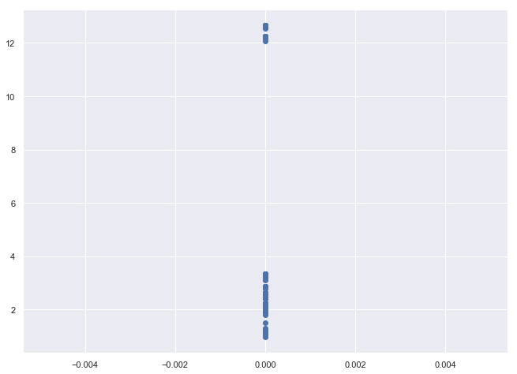

```python
plt.scatter(y_hidd_time,pred_lstm)
```

# Clustering

```python
dttest_clus=pd.read_csv("C:\\Users\\Subhasish Das\\Desktop\\SimplyLearn\\Project\\AICapston\\Retail-Datasets\\test_data.csv")
dttr_clus=pd.read_csv("C:\\Users\\Subhasish Das\\Desktop\\SimplyLearn\\Project\\AICapston\\Retail-Datasets\\train_data.csv")
dthidd_clus=pd.read_csv("C:\\Users\\Subhasish Das\\Desktop\\SimplyLearn\\Project\\AICapston\\Retail-Datasets\\test_data_hidden.csv")
```

```
C:\Users\Subhasish Das\Anaconda3\lib\site-packages\IPython\core\interactiveshell.py:3049: DtypeWarning: Columns (7) have mixed types. Specify dtype option on import or set low_memory=False.
  interactivity=interactivity, compiler=compiler, result=result)
```

```python
dtmer_clus=pd.concat([dttr_clus,dthidd_clus])
```

```python
dtmer_clus.drop('Date',axis=1,inplace=True)
```

```python
dtmer_clus.drop('StateHoliday',axis=1,inplace=True)
```

```python
dtmer_clus.columns
```

```
Index(['Store', 'DayOfWeek', 'Sales', 'Customers', 'Open', 'Promo',
       'SchoolHoliday'],
      dtype='object')
```

```python
dtmer_clus.drop(['DayOfWeek','Open','Promo','SchoolHoliday'],axis=1,inplace=True)
```

```python
dtmer_clus.columns
```

```
Index(['Store', 'Sales', 'Customers'], dtype='object')
```

```python
from sklearn.preprocessing import StandardScaler
scaler = StandardScaler()
data_scaled = scaler.fit_transform(dtmer_clus)
```

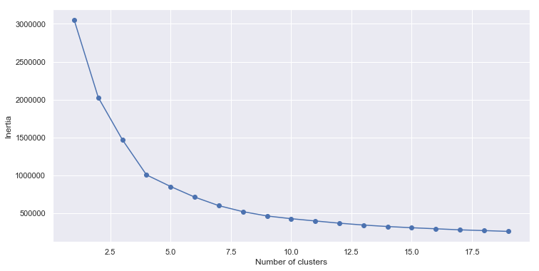

```python
from sklearn.cluster import KMeans
SSE = []
for cluster in range(1,20):
    kmeans = KMeans(n_jobs = -1, n_clusters = cluster, init='k-means++')
    kmeans.fit(data_scaled)
    SSE.append(kmeans.inertia_)

# converting the results into a dataframe and plotting them
frame = pd.DataFrame({'Cluster':range(1,20), 'SSE':SSE})
plt.figure(figsize=(12,6))
plt.plot(frame['Cluster'], frame['SSE'], marker='o')
plt.xlabel('Number of clusters')
plt.ylabel('Inertia')
```

```python
kmeans = KMeans(n_clusters=5).fit(dtmer_clus)
centroids = kmeans.cluster_centers_
print(centroids)
label=kmeans.predict(dtmer_clus)
```

```
[[5.59130697e+02 4.49681921e+03 5.21073020e+02]
 [5.64397077e+02 1.05415161e+04 1.10562809e+03]
 [5.53071159e+02 7.14630551e+03 7.67057297e+02]
 [5.58564108e+02 1.07817560e+02 1.36869614e+01]
 [5.78347375e+02 1.68774786e+04 1.95064383e+03]]
```

```python
dtmer_clus['Cluster']=label
```

```python
dtmer_clus.head()
```

|  | Store | Sales | Customers | Cluster |
| --- | --- | --- | --- | --- |
| 0 | 1 | 5735 | 568 | 0 |
| 1 | 2 | 9863 | 877 | 1 |
| 2 | 3 | 13261 | 1072 | 1 |
| 3 | 4 | 13106 | 1488 | 1 |
| 4 | 5 | 6635 | 645 | 2 |

```python
dtmer_clus.Cluster.unique()
```

```
array([0, 1, 2, 4, 3], dtype=int64)
```

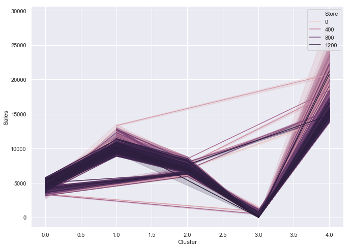

```python
sns.lineplot(data=dtmer_clus, x='Cluster', y='Sales',hue='Store');
```

```
C:\Users\Subhasish Das\Anaconda3\lib\site-packages\pandas\plotting\_core.py:1001: UserWarning: Attempting to set identical left==right results
in singular transformations; automatically expanding.
left=4.0, right=4.0
  ax.set_xlim(left, right)
```

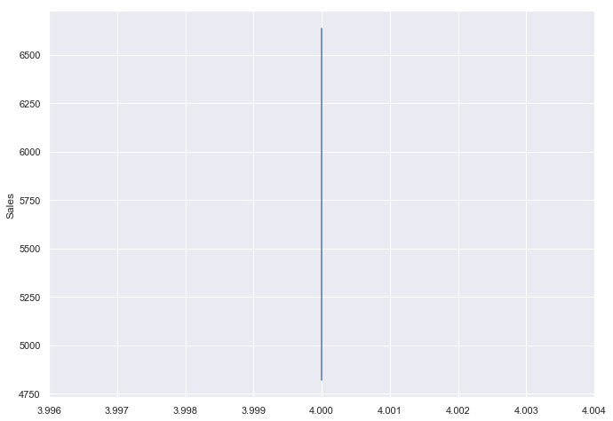

```python
ax = dtmer_clus.loc[4, 'Sales'].plot()
ax.set_ylabel('Sales');
```

```
C:\Users\Subhasish Das\Anaconda3\lib\site-packages\pandas\plotting\_core.py:1001: UserWarning: Attempting to set identical left==right results
in singular transformations; automatically expanding.
left=3.0, right=3.0
  ax.set_xlim(left, right)
```

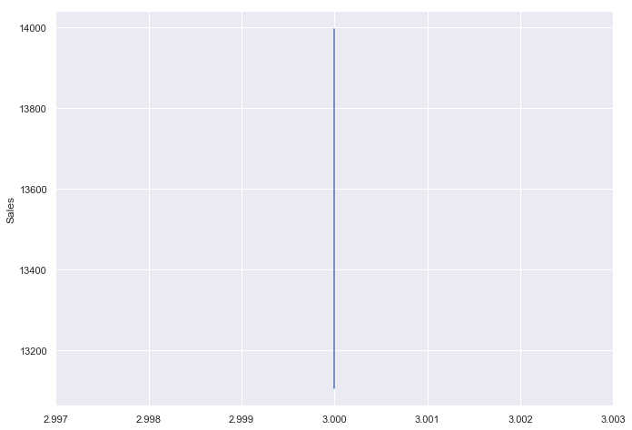

```python
ax = dtmer_clus.loc[3, 'Sales'].plot()
ax.set_ylabel('Sales');
```

```
C:\Users\Subhasish Das\Anaconda3\lib\site-packages\pandas\plotting\_core.py:1001: UserWarning: Attempting to set identical left==right results
in singular transformations; automatically expanding.
left=2.0, right=2.0
  ax.set_xlim(left, right)
```

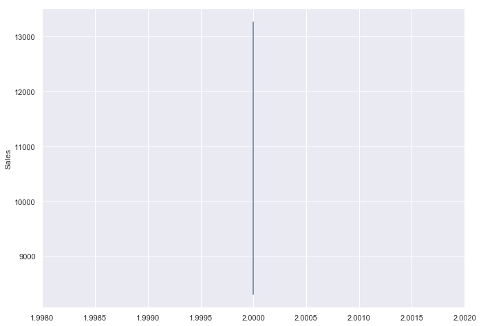

```python
ax = dtmer_clus.loc[2, 'Sales'].plot()
ax.set_ylabel('Sales');
```

```
C:\Users\Subhasish Das\Anaconda3\lib\site-packages\pandas\plotting\_core.py:1001: UserWarning: Attempting to set identical left==right results
in singular transformations; automatically expanding.
left=1.0, right=1.0
  ax.set_xlim(left, right)
```

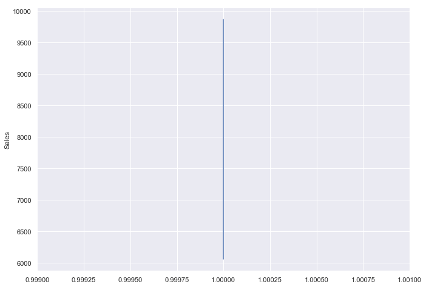

```python
ax = dtmer_clus.loc[1, 'Sales'].plot()
ax.set_ylabel('Sales');
```

```
C:\Users\Subhasish Das\Anaconda3\lib\site-packages\pandas\plotting\_core.py:1001: UserWarning: Attempting to set identical left==right results
in singular transformations; automatically expanding.
left=0.0, right=0.0
  ax.set_xlim(left, right)
```

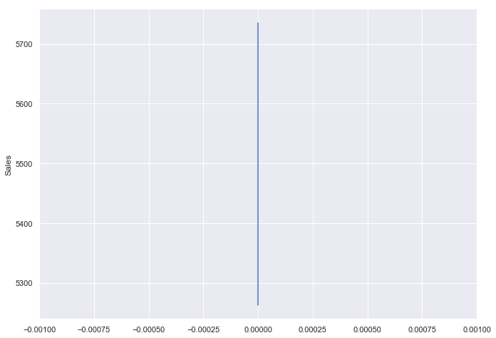

```python
ax = dtmer_clus.loc[0, 'Sales'].plot()
ax.set_ylabel('Sales');
```

## Project Task: Week 4

**Applying ANN:**

1. Use ANN (Artificial Neural Network) to predict Store Sales. a. Fine-tune number of layers.

   b. Number of Neurons in each layers.

   c. Experiment in batch-size.

   d. Experiment with number of epochs. Carefully observe the loss and accuracy? What are the observations?

   e. Play with different Learning Rate variants of Gradient Descent like Adam, SGD, RMS-prop.

   f. Which activation performs best for this use case and why?

   g. Check how it performed in the dataset, calculate RMSE.
1. Use Dropout for ANN and find the optimum number of clusters (clusters formed considering the features: sales and customer visits). Compare model performance with traditional ML based prediction models.
1. Find the best setting of neural net that minimizes the loss and can predict the sales best. Use techniques like Grid search, cross-validation and Random search.

### Code :

# ANN Model

```python
import tensorflow as tf
```

```python
dttest_Ann=pd.read_csv("C:\\Users\\Subhasish Das\\Desktop\\SimplyLearn\\Project\\AICapston\\Retail-Datasets\\test_data.csv")
dttr_Ann=pd.read_csv("C:\\Users\\Subhasish Das\\Desktop\\SimplyLearn\\Project\\AICapston\\Retail-Datasets\\train_data.csv")
dthidd_Ann=pd.read_csv("C:\\Users\\Subhasish Das\\Desktop\\SimplyLearn\\Project\\AICapston\\Retail-Datasets\\test_data_hidden.csv")
```

```
C:\Users\Subhasish Das\Anaconda3\lib\site-packages\IPython\core\interactiveshell.py:3049: DtypeWarning: Columns (7) have mixed types. Specify dtype option on import or set low_memory=False.
  interactivity=interactivity, compiler=compiler, result=result)
```

```python
dttest_Ann.drop(['Date','StateHoliday'],axis=1,inplace=True)
```

```python
dttr_Ann.drop(['Date','StateHoliday'],axis=1,inplace=True)
```

```python
dthidd_Ann.drop(['Date','StateHoliday'],axis=1,inplace=True)
```

```python
min_dt=dttr_Ann.min()
```

```python
range_dt=(dttr_Ann-min_dt).max()
dttr_Ann = (dttr_Ann-min_dt)/range_dt
```

```python
dttr_Ann.head()
```

|  | Store | DayOfWeek | Sales | Customers | Open | Promo | SchoolHoliday |
| --- | --- | --- | --- | --- | --- | --- | --- |
| 0 | 0.000000 | 0.166667 | 0.138023 | 0.076881 | 1.0 | 1.0 | 0.0 |
| 1 | 0.000898 | 0.166667 | 0.237371 | 0.118706 | 1.0 | 1.0 | 0.0 |
| 2 | 0.001795 | 0.166667 | 0.319150 | 0.145100 | 1.0 | 1.0 | 1.0 |
| 3 | 0.002693 | 0.166667 | 0.315420 | 0.201408 | 1.0 | 1.0 | 0.0 |
| 4 | 0.003591 | 0.166667 | 0.159683 | 0.087304 | 1.0 | 1.0 | 0.0 |

```python
dttr_Ann.drop('Store',axis=1,inplace=True)
```

```python
min_dt_1=dthidd_Ann.min()
range_dt_1=(dthidd_Ann-min_dt_1).max()
dthidd_Ann = (dthidd_Ann-min_dt_1)/range_dt_1
```

```python
dthidd_Ann.head()
```

|  | Store | DayOfWeek | Sales | Customers | Open | Promo | SchoolHoliday |
| --- | --- | --- | --- | --- | --- | --- | --- |
| 0 | 0.000000 | 0.666667 | 0.161705 | 0.116036 | 1.0 | 1.0 | 1.0 |
| 1 | 0.000898 | 0.666667 | 0.186315 | 0.130671 | 1.0 | 1.0 | 1.0 |
| 2 | 0.001795 | 0.666667 | 0.255446 | 0.171650 | 1.0 | 1.0 | 1.0 |
| 3 | 0.002693 | 0.666667 | 0.429994 | 0.313193 | 1.0 | 1.0 | 1.0 |
| 4 | 0.003591 | 0.666667 | 0.148155 | 0.116872 | 1.0 | 1.0 | 1.0 |

```python
dthidd_Ann.drop('Store',axis=1,inplace=True)
```

```python
min_dt2=dttest_Ann.min()
range_dt2=(dttest_Ann-min_dt2).max()
dttest_Ann=(dttest_Ann-min_dt2)/range_dt2
```

```python
dttest_Ann.head()
```

|  | Store | DayOfWeek | Customers | Open | Promo | SchoolHoliday |
| --- | --- | --- | --- | --- | --- | --- |
| 0 | 0.000000 | 0.666667 | 0.116036 | 1.0 | 1.0 | 1.0 |
| 1 | 0.000898 | 0.666667 | 0.130671 | 1.0 | 1.0 | 1.0 |
| 2 | 0.001795 | 0.666667 | 0.171650 | 1.0 | 1.0 | 1.0 |
| 3 | 0.002693 | 0.666667 | 0.313193 | 1.0 | 1.0 | 1.0 |
| 4 | 0.003591 | 0.666667 | 0.116872 | 1.0 | 1.0 | 1.0 |

```python
dttest_Ann.drop('Store',axis=1,inplace=True)
```

```python
x_tr_Ann=dttr_Ann.drop('Sales',axis=1)
y_tr_Ann=dttr_Ann['Sales']
```

```python
x_hidd_Ann=dthidd_Ann.drop('Sales',axis=1)
y_hidd_Ann=dthidd_Ann['Sales']
```

```python
x_tr_Ann.shape
```

```
(982644, 5)
```

```python
x_hidd_Ann.shape
```

```
(34565, 5)
```

```python
model=tf.keras.models.Sequential()
model.add(tf.keras.layers.BatchNormalization(input_shape=(5,)))
model.add(tf.keras.layers.Dense(512,activation='relu'))
model.add(tf.keras.layers.BatchNormalization())
model.add(tf.keras.layers.Dense(256,activation='relu'))
model.add(tf.keras.layers.BatchNormalization())
model.add(tf.keras.layers.Dense(128,activation='relu'))
model.add(tf.keras.layers.BatchNormalization())
model.add(tf.keras.layers.Dense(64,activation='relu'))
#model.add(tf.keras.layers.Dropout(0.2))
model.add(tf.keras.layers.BatchNormalization())
model.add(tf.keras.layers.Dense(32,activation='relu'))
#model.add(tf.keras.layers.Dropout(0.2))
model.add(tf.keras.layers.BatchNormalization())
model.add(tf.keras.layers.Dense(16,activation='relu'))
#model.add(tf.keras.layers.Dropout(0.2))
model.add(tf.keras.layers.BatchNormalization())
model.add(tf.keras.layers.Dense(8,activation='relu'))
#model.add(tf.keras.layers.Dropout(0.2))
model.add(tf.keras.layers.BatchNormalization())
model.add(tf.keras.layers.Dense(1,activation='sigmoid'))
```

```python
sgd_op=tf.keras.optimizers.SGD(lr=0.3)
model.compile(optimizer=sgd_op,loss='mse',metrics=['accuracy'])
```

```python
model.summary()
```

```
Model: "sequential"
_________________________________________________________________
Layer (type)                 Output Shape              Param #
=================================================================
batch_normalization (BatchNo (None, 5)                 20
_________________________________________________________________
dense (Dense)                (None, 512)               3072
_________________________________________________________________
batch_normalization_1 (Batch (None, 512)               2048
_________________________________________________________________
dense_1 (Dense)              (None, 256)               131328
_________________________________________________________________
batch_normalization_2 (Batch (None, 256)               1024
_________________________________________________________________
dense_2 (Dense)              (None, 128)               32896
_________________________________________________________________
batch_normalization_3 (Batch (None, 128)               512
_________________________________________________________________
dense_3 (Dense)              (None, 64)                8256
_________________________________________________________________
batch_normalization_4 (Batch (None, 64)                256
_________________________________________________________________
dense_4 (Dense)              (None, 32)                2080
_________________________________________________________________
batch_normalization_5 (Batch (None, 32)                128
_________________________________________________________________
dense_5 (Dense)              (None, 16)                528
_________________________________________________________________
batch_normalization_6 (Batch (None, 16)                64
_________________________________________________________________
dense_6 (Dense)              (None, 8)                 136
_________________________________________________________________
batch_normalization_7 (Batch (None, 8)                 32
_________________________________________________________________
dense_7 (Dense)              (None, 1)                 9
=================================================================
Total params: 182,389
Trainable params: 180,347
Non-trainable params: 2,042
_________________________________________________________________
```

```python
early_stopping_cb=tf.keras.callbacks.EarlyStopping(patience=10,restore_best_weights=True)
model.fit(x_tr_Ann,y_tr_Ann,epochs=50,validation_data=(x_hidd_Ann,y_hidd_Ann),callbacks=[early_stopping_cb])
```

```
WARNING:tensorflow:Falling back from v2 loop because of error: Failed to find data adapter that can handle input: <class 'pandas.core.frame.DataFrame'>, <class 'NoneType'>
Train on 982644 samples, validate on 34565 samples
```

```
<tensorflow.python.keras.callbacks.History at 0x2592e827e80>
```

```python
predann=model.predict(dttest_Ann)
```

```
WARNING:tensorflow:Falling back from v2 loop because of error: Failed to find data adapter that can handle input: <class 'pandas.core.frame.DataFrame'>, <class 'NoneType'>
```

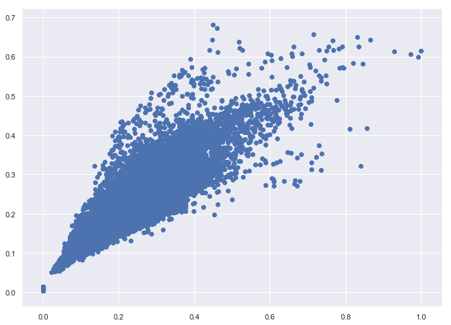

```python
plt.scatter(y_hidd_Ann,predann)
```

```python
print('MAE',mean_absolute_error(y_hidd_Ann,predann))
print('MSE',mean_squared_error(y_hidd_Ann,predann))
print('RMSE',np.sqrt(mean_squared_error(y_hidd_Ann,predann)))
print('R2 score',r2_score(y_hidd_Ann,predann))
```

```
MAE 0.031306250576291696
MSE 0.0019958009051368095
RMSE 0.04467438757427806
R2 score 0.8374397774318014
```

# Creating a new model by adding dropout

```python
model1=tf.keras.models.Sequential()
model1.add(tf.keras.layers.BatchNormalization(input_shape=(5,)))
model1.add(tf.keras.layers.Dense(32,activation='relu'))
model1.add(tf.keras.layers.Dropout(0.2))
model1.add(tf.keras.layers.BatchNormalization())
model1.add(tf.keras.layers.Dense(16,activation='relu'))
model1.add(tf.keras.layers.Dropout(0.2))
model1.add(tf.keras.layers.BatchNormalization())
model1.add(tf.keras.layers.Dense(8,activation='relu'))
model1.add(tf.keras.layers.Dropout(0.2))
model1.add(tf.keras.layers.BatchNormalization())
model1.add(tf.keras.layers.Dense(1,activation='sigmoid'))
```

```python
adam_op=tf.keras.optimizers.Adam(lr=0.5)
model1.compile(optimizer=adam_op,loss='mse',metrics=['accuracy'])
```

```python
model1.summary()
```

```
Model: "sequential_1"
_________________________________________________________________
Layer (type)                 Output Shape              Param #
=================================================================
batch_normalization_8 (Batch (None, 5)                 20
_________________________________________________________________
dense_8 (Dense)              (None, 32)                192
_________________________________________________________________
dropout (Dropout)            (None, 32)                0
_________________________________________________________________
batch_normalization_9 (Batch (None, 32)                128
_________________________________________________________________
dense_9 (Dense)              (None, 16)                528
_________________________________________________________________
dropout_1 (Dropout)          (None, 16)                0
_________________________________________________________________
batch_normalization_10 (Batc (None, 16)                64
_________________________________________________________________
dense_10 (Dense)             (None, 8)                 136
_________________________________________________________________
dropout_2 (Dropout)          (None, 8)                 0
_________________________________________________________________
batch_normalization_11 (Batc (None, 8)                 32
_________________________________________________________________
dense_11 (Dense)             (None, 1)                 9
=================================================================
Total params: 1,109
Trainable params: 987
Non-trainable params: 122
_________________________________________________________________
```

```python
early_stopping_cb=tf.keras.callbacks.EarlyStopping(patience=10,restore_best_weights=True)
model1.fit(x_tr_Ann,y_tr_Ann,validation_data=(x_hidd_Ann,y_hidd_Ann),epochs=30,batch_size=64,callbacks=[early_stopping_cb])
```

```
WARNING:tensorflow:Falling back from v2 loop because of error: Failed to find data adapter that can handle input: <class 'pandas.core.frame.DataFrame'>, <class 'NoneType'>
Train on 982644 samples, validate on 34565 samples
```

```
<tensorflow.python.keras.callbacks.History at 0x25912747dd8>
```

```python
predann1=model1.predict(dttest_Ann)
```

```
WARNING:tensorflow:Falling back from v2 loop because of error: Failed to find data adapter that can handle input: <class 'pandas.core.frame.DataFrame'>, <class 'NoneType'>
```

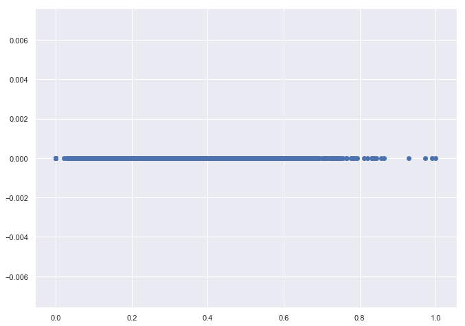

```python
plt.scatter(y_hidd_Ann,predann1)
```

```python
print('MAE',mean_absolute_error(y_hidd_Ann,predann1))
print('MSE',mean_squared_error(y_hidd_Ann,predann1))
print('RMSE',np.sqrt(mean_squared_error(y_hidd_Ann,predann1)))
print('R2 score',r2_score(y_hidd_Ann,predann1))
```

```
MAE 0.1887333859143828
MSE 0.04789759270944478
RMSE 0.2188551866176463
R2 score -2.901312656632216
```

```python
model2=tf.keras.models.Sequential()
model2.add(tf.keras.layers.BatchNormalization(input_shape=(5,)))
model2.add(tf.keras.layers.Dense(8,activation='relu'))
model2.add(tf.keras.layers.Dropout(0.2))
model2.add(tf.keras.layers.BatchNormalization())
model2.add(tf.keras.layers.Dense(1,activation='softmax'))
```

```python
adam_op=tf.keras.optimizers.Adam(lr=0.7)
model2.compile(optimizer=adam_op,loss='mse',metrics=['accuracy'])
```

```python
early_stopping_cb=tf.keras.callbacks.EarlyStopping(patience=10,restore_best_weights=True)
model2.fit(x_tr_Ann,y_tr_Ann,validation_data=(x_hidd_Ann,y_hidd_Ann),epochs=40,batch_size=128,callbacks=[early_stopping_cb])
```

```
WARNING:tensorflow:Falling back from v2 loop because of error: Failed to find data adapter that can handle input: <class 'pandas.core.frame.DataFrame'>, <class 'NoneType'>
Train on 982644 samples, validate on 34565 samples
```

```
<tensorflow.python.keras.callbacks.History at 0x2595a7da320>
```

```python
predann2=model2.predict(dttest_Ann)
```

```
WARNING:tensorflow:Falling back from v2 loop because of error: Failed to find data adapter that can handle input: <class 'pandas.core.frame.DataFrame'>, <class 'NoneType'>
```

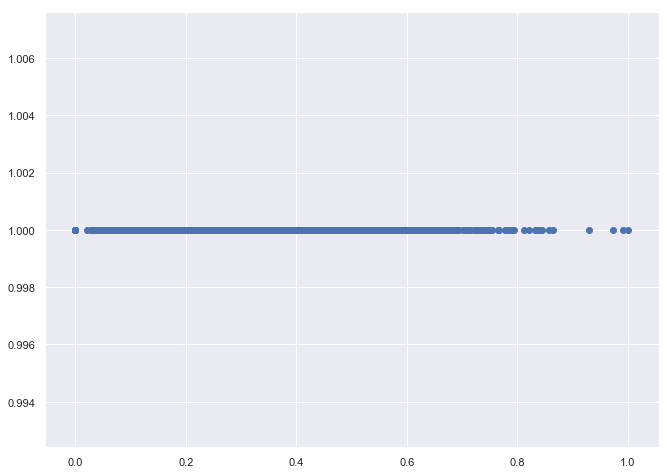

```python
plt.scatter(y_hidd_Ann,predann2)
```

```python
print('MAE',mean_absolute_error(y_hidd_Ann,predann2))
print('MSE',mean_squared_error(y_hidd_Ann,predann2))
print('RMSE',np.sqrt(mean_squared_error(y_hidd_Ann,predann2)))
print('R2 score',r2_score(y_hidd_Ann,predann2))
```

```
MAE 0.8112666140856171
MSE 0.670430820880679
RMSE 0.8187984006339283
R2 score -53.60734243502732
```

###### Observation - 12

> From the above 3 ANN models we can say that the first model is better beacuse it has lowest RMSE score

# Applying Gridseach

```python
from sklearn.model_selection import GridSearchCV
from keras.wrappers.scikit_learn import KerasRegressor
#keras_reg = keras.wrappers.scikit_learn.KerasRegressor(build_model)
from keras.wrappers.scikit_learn import KerasClassifier
```

```python
def create_model():
    # create model
    model=tf.keras.models.Sequential()
    model.add(tf.keras.layers.BatchNormalization(input_shape=(5,)))
    model.add(tf.keras.layers.Dense(128,activation='relu'))
    model.add(tf.keras.layers.Dense(64, activation='relu'))
    model.add(tf.keras.layers.Dense(1,activation='sigmoid'))
    adam_op=tf.keras.optimizers.Adam()
    model.compile(optimizer=adam_op,loss='mean_squared_error',metrics=['mse'])
    #model.compile(loss='mean_squared_error', optimizer=optimizer,metrics=['mse'])
    return model
```

```python
x_tr_Ann = np.asarray(x_tr_Ann)
```

```python
y_tr_Ann = np.asarray(y_tr_Ann)
```

```python
x_hidd_Ann = np.asarray(x_hidd_Ann)
```

```python
y_hidd_Ann = np.asarray(y_hidd_Ann)
```

```python
early_stopping_cb=tf.keras.callbacks.EarlyStopping(patience=10,restore_best_weights=True)
```

```python
def build_model(n_neurons=30, learning_rate=0.1, input_shape=[5]):
    model = tf.keras.models.Sequential()
    model.add(tf.keras.layers.InputLayer(input_shape))
    model.add(tf.keras.layers.Dense(n_neurons, activation="relu"))
    model.add(tf.keras.layers.Dense(1))
    sgd = tf.keras.optimizers.SGD(lr=learning_rate)
    model.compile(loss="mse", optimizer=sgd,metrics=['accuracy'])
    return model
```

```python
#keras_reg = keras.wrappers.scikit_learn.KerasRegressor(build_model)
keras_reg = KerasRegressor(build_model)
params_distrib = {'batch_size': [25, 32],
                  'epochs': [10]}
rnd_search_cv = GridSearchCV(keras_reg, params_distrib,cv=3)
rnd_search_cv.fit(x_tr_Ann, y_tr_Ann, epochs=5,
                    validation_data=(x_hidd_Ann,y_hidd_Ann),callbacks=[early_stopping_cb])
```

```
Train on 655096 samples, validate on 34565 samples
```

[output not shown]

```
Train on 655096 samples, validate on 34565 samples
```

[output not shown]

```
Train on 655096 samples, validate on 34565 samples
```

[output not shown]

```
Train on 655096 samples, validate on 34565 samples
```

[output not shown]

```
Train on 655096 samples, validate on 34565 samples
```

[output not shown]

```
Train on 655096 samples, validate on 34565 samples
```

[output not shown]

```
Train on 982644 samples, validate on 34565 samples
```

```
GridSearchCV(cv=3, error_score='raise-deprecating',
             estimator=<keras.wrappers.scikit_learn.KerasRegressor object at 0x000002596F241860>,
             iid='warn', n_jobs=None,
             param_grid={'batch_size': [25, 32], 'epochs': [10]},
             pre_dispatch='2*n_jobs', refit=True, return_train_score=False,
             scoring=None, verbose=0)
```

```python
rnd_search_cv.best_params_
```

```
{'batch_size': 32, 'epochs': 10}
```

```python
rnd_search_cv.best_score_
```

```
-0.001125427730409144
```

```python
grid_pred=rnd_search_cv.predict(dttest_Ann)
```

```
WARNING:tensorflow:Falling back from v2 loop because of error: Failed to find data adapter that can handle input: <class 'pandas.core.frame.DataFrame'>, <class 'NoneType'>
```

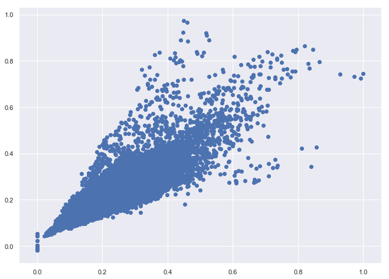

```python
plt.scatter(y_hidd_Ann,grid_pred)
```

```python
print('MAE',mean_absolute_error(y_hidd_Ann,grid_pred))
print('MSE',mean_squared_error(y_hidd_Ann,grid_pred))
print('RMSE',np.sqrt(mean_squared_error(y_hidd_Ann,grid_pred)))
print('R2 score',r2_score(y_hidd_Ann,grid_pred))
```

```
MAE 0.030874397893976547
MSE 0.0021287145885606185
RMSE 0.04613799506437854
R2 score 0.8266138088173357
```